# Group Project: Project plan & Initial Data Analysis (IDA)

STAT5003

Group 38

Members:

- Quynh Giang Le - 530190754
- Kairui Huang - 530261917
- Rundong Shen - 530023418
- Haoyu Fang - 540576287
- Wanxin Bao - 540320288

```r
suppressPackageStartupMessages(library('tidyverse'))
```

```r
suppressPackageStartupMessages(library('readr'))
suppressPackageStartupMessages(library('dplyr'))
suppressPackageStartupMessages(library('ggplot2'))
suppressPackageStartupMessages(library('broom'))
suppressPackageStartupMessages(library('tinytex'))
suppressPackageStartupMessages(library('caret'))
suppressPackageStartupMessages(library('gridExtra'))

data <- as.data.frame(read.csv("credit_train.csv", header = TRUE))
```

This dataset is from  
Rohan Paris. (2022). Credit score classification [dataset]. Kaggle. https://www.kaggle.com/datasets/parisrohan/credit-score-classification

# 1 Problem Overview

The purpose of this task is to construct a credit rating classification model based on existing data from banks, such as loan quantity, number of delayed payments, etc. After receiving user personal data, users are divided into pre-set different credit risk levels. This is a supervised learning task, where the training data has a known label, namely Credit_Score, and the label is discrete, making it a classification problem.  
This task is interesting and has practical significance. Credit scoring is widely used in banks and other financial institutions. By constructing a classification model for credit scoring, it can effectively improve classification efficiency and reduce labor costs. When dealing with large amounts of lending data, this model will be particularly effective. At the same time, the model also improves the standardization of classification, ensuring the accuracy and objectivity of credit ratings, which helps credit ratings be accepted by consumers. From a technical perspective, building an efficient and accurate scoring model poses many challenges, including data cleaning, feature selection, model optimization, and so on. This task can help beginners master the basic knowledge of data science, understand the advantages and disadvantages of different models, and explore how to improve the performance of models. This is both a challenge and an interesting research process.

# 2 Dataset Description

## 2.1 Description

```r
str(data)
```

```
## 'data.frame':    100000 obs. of  28 variables:
##  $ ID                      : num  5634 5635 5636 5637 5638 ...
##  $ Customer_ID             : chr  "CUS_0xd40" "CUS_0xd40" "CUS_0xd40" "CUS_0xd40" ...
##  $ Month                   : chr  "January" "February" "March" "April" ...
##  $ Name                    : chr  "Aaron Maashoh" "Aaron Maashoh" "Aaron Maashoh" "Aaron Maashoh" ...
##  $ Age                     : chr  "23" "23" "-500" "23" ...
##  $ SSN                     : chr  "821-00-0265" "821-00-0265" "821-00-0265" "821-00-0265" ...
##  $ Occupation              : chr  "Scientist" "Scientist" "Scientist" "Scientist" ...
##  $ Annual_Income           : chr  "19114.12" "19114.12" "19114.12" "19114.12" ...
##  $ Monthly_Inhand_Salary   : num  1825 NA NA NA 1825 ...
##  $ Num_Bank_Accounts       : int  3 3 3 3 3 3 3 3 2 2 ...
##  $ Num_Credit_Card         : int  4 4 4 4 4 4 4 4 4 4 ...
##  $ Interest_Rate           : int  3 3 3 3 3 3 3 3 6 6 ...
##  $ Num_of_Loan             : chr  "4" "4" "4" "4" ...
##  $ Type_of_Loan            : chr  "Auto Loan, Credit-Builder Loan, Personal Loan, and Home Equity Loan" "Auto Loan, Credit-Builder Loan, Personal Loan, and Home Equity Loan" "Auto Loan, Credit-Builder Loan, Personal Loan, and Home Equity Loan" "Auto Loan, Credit-Builder Loan, Personal Loan, and H…
##  $ Delay_from_due_date     : int  3 -1 3 5 6 8 3 3 3 7 ...
##  $ Num_of_Delayed_Payment  : chr  "7" "" "7" "4" ...
##  $ Changed_Credit_Limit    : chr  "11.27" "11.27" "_" "6.27" ...
##  $ Num_Credit_Inquiries    : num  4 4 4 4 4 4 4 4 2 2 ...
##  $ Credit_Mix              : chr  "_" "Good" "Good" "Good" ...
##  $ Outstanding_Debt        : chr  "809.98" "809.98" "809.98" "809.98" ...
##  $ Credit_Utilization_Ratio: num  26.8 31.9 28.6 31.4 24.8 ...
##  $ Credit_History_Age      : chr  "22 Years and 1 Months" NA "22 Years and 3 Months" "22 Years and 4 Months" ...
##  $ Payment_of_Min_Amount   : chr  "No" "No" "No" "No" ...
##  $ Total_EMI_per_month     : num  49.6 49.6 49.6 49.6 49.6 ...
##  $ Amount_invested_monthly : chr  "80.41529543900253" "118.28022162236736" "81.699521264648" "199.4580743910713" ...
##  $ Payment_Behaviour       : chr  "High_spent_Small_value_payments" "Low_spent_Large_value_payments" "Low_spent_Medium_value_payments" "Low_spent_Small_value_payments" ...
##  $ Monthly_Balance         : chr  "312.49408867943663" "284.62916249607184" "331.2098628537912" "223.45130972736786" ...
##  $ Credit_Score            : chr  "Good" "Good" "Good" "Good" ...
```

## 2.2 Dataset challenges

In this task, the dataset contains 100000 samples, with a large number of missing values that need to be supplemented in different ways. Filling in a large number of missing values will be a challenge. At the same time, it is necessary to handle various types of erroneous values during research, such as underline, values that clearly exceed the normal range, etc. This will involve a series of tasks such as data cleaning and data type conversion. Meanwhile, the model needs to solve a Multi class classification problem, which is also a challenge.

# 3 Data cleaning

## 3.1 Initial cleaning

**1. Check for duplicated rows**

```r
sum(duplicated(data))
```

```
## [1] 0
```

**2. Remove unnecessary columns**

```r
data <- data[ , -which(names(data) %in% c("ID", "Name", "SSN"))]
```

**3. Change value for Credit_History_Age column**

```r
data["Credit_History_Age"] = lapply(data["Credit_History_Age"], function(x) {
    years <- as.integer(sub("\\Years.*", "", x))
    months <- as.integer(sub(".*\\d+\\s+Years\\s+and\\s+(\\d+)\\s+Months.*", "\\1", x))
    return(years*12 + months)
})
```

## 3.2 Numerical variables

In this section, we would perform some visualization to see the distribution of some numerical variables, some checking functions to comprehend the pattern of these variables. As the result, we would do some modification to missing values and inappropriate outliers.

**1. Delete leading/trailing “_” in some columns**

```r
for(i in c("Age","Annual_Income", "Num_of_Loan", "Num_of_Delayed_Payment",
                    "Changed_Credit_Limit", "Outstanding_Debt", "Amount_invested_monthly", "Monthly_Balance")) {
  data[[i]] <- gsub("_", "", data[[i]])

  data[[i]] <- as.numeric(data[[i]])
}
```

**2. Declare supporting functions**

```r
# This is a function to find the bound of the column by using IQR
calculate_bounds <- function(column_name) {
  Q1 <- quantile(data[[column_name]], 0.25, na.rm = TRUE)
  Q3 <- quantile(data[[column_name]], 0.75, na.rm = TRUE)
  IQR <- Q3 - Q1
  lower_bound <- Q1 - 1.5 * IQR
  upper_bound <- Q3 + 1.5 * IQR
  return(c(lower_bound, upper_bound))
}

# This is a function to check if each group has a unique value
analyze_unique_values <- function(income_column) {
  lower_bound <- calculate_bounds(income_column)[1]
  upper_bound <- calculate_bounds(income_column)[2]

  filtered_data <- data %>%
    filter(!!sym(income_column) >= lower_bound & !!sym(income_column) <= upper_bound)

  result <- filtered_data %>%
    group_by(Customer_ID) %>%
    summarise(Unique_Value_Count = n_distinct(!!sym(income_column)),
              Only_One_Unique_Value = Unique_Value_Count == 1) %>%
    ungroup()

  if(all(result$Only_One_Unique_Value)) {
    return (TRUE)
  } else {
    return (FALSE)
  }
}

# This is a function to change outliers with neighbor
clean_data_with_neighbor <- function(column_name, lower_bound, upper_bound) {
  column_sym <- sym(column_name)
  result <- data %>%
    group_by(Customer_ID) %>%
    mutate(
      !!column_sym := ifelse(
        .data[[column_name]] < lower_bound | .data[[column_name]] > upper_bound, NA, .data[[column_name]]
      )
    ) %>%
    fill(!!column_sym, .direction = "up") %>%
    fill(!!column_sym, .direction = "down") %>%
    ungroup()

  return(result)
}

# This is a function that can find the most common value in every column
find_mode <- function(x) {
  ux <- unique(na.omit(x))
  ux[which.max(tabulate(match(x, ux)))]
}

# This is a function to change outliers with mode
clean_data_with_mode <- function(column_name) {
  col_sym <- rlang::sym(column_name)
  result <- data %>%
    group_by(Customer_ID) %>%
    mutate(Mode = find_mode(!!col_sym),
           !!col_sym := Mode) %>%
    select(-Mode) %>%
    ungroup()
  return(result)
}

# This is a function to fill NA with neighbor
fill_NA_with_neighbour <- function(column_name) {
  result <- data %>%
    group_by(Customer_ID) %>%
    fill(!!rlang::sym(column_name), .direction = "up") %>%
    fill(!!rlang::sym(column_name), .direction = "down") %>%
    ungroup()

  return(result)
}

# This is a function to replace negative value with 0
replace_negative_with_0 <- function(column_name) {
  result <- data %>%
    mutate(!!rlang::sym(column_name) := ifelse(!!rlang::sym(column_name) < 0, 0, !!rlang::sym(column_name)))

  return(result)
}

# This is a function to fill NA with mean
fill_NA_with_mean <- function(column_name) {
  col_sym <- rlang::sym(column_name)
  result <- data %>%
    group_by(Customer_ID) %>%
    mutate(
      Mean = round(mean({{col_sym}}[!is.na({{col_sym}})], na.rm = TRUE), 2),
      {{col_sym}} := if_else(is.na({{col_sym}}), Mean, {{col_sym}})
    ) %>%
    select(-Mean) %>%
    ungroup()
  return(result)
}

# This is a function to replace the outliers and NA with mean
replace_with_group_mean <- function(column_name, value_to_replace) {
  col_sym <- sym(column_name)
  result <- data %>%
    group_by(Customer_ID) %>%
    mutate(
      Group_Mean = mean({{col_sym}}[{{col_sym}} != value_to_replace & !is.na({{col_sym}})], na.rm = TRUE),
      {{col_sym}} := if_else({{col_sym}} == value_to_replace | is.na({{col_sym}}), Group_Mean, {{col_sym}})
    ) %>%
    select(-Group_Mean) %>%
    ungroup()
  return(result)
}
```

**3. Check the values of all numerical variables**

**3.1. Check missing value percentages**

```r
missing_values <- colSums(is.na(data[c("Age", "Annual_Income", "Monthly_Inhand_Salary", "Num_Bank_Accounts",
                                       "Num_Credit_Card", "Interest_Rate", "Num_of_Loan",
                                       "Delay_from_due_date", "Num_of_Delayed_Payment",
                                       "Changed_Credit_Limit", "Num_Credit_Inquiries",
                                       "Outstanding_Debt", "Credit_Utilization_Ratio",
                                       "Credit_History_Age", "Total_EMI_per_month",
                                       "Amount_invested_monthly", "Monthly_Balance")]))


total_values <- nrow(data)

missing_values_percent <- missing_values / total_values * 100

missing_values_percent
```

```
##                      Age            Annual_Income    Monthly_Inhand_Salary
##                    0.000                    0.000                   15.002
##        Num_Bank_Accounts          Num_Credit_Card            Interest_Rate
##                    0.000                    0.000                    0.000
##              Num_of_Loan      Delay_from_due_date   Num_of_Delayed_Payment
##                    0.000                    0.000                    7.002
##     Changed_Credit_Limit     Num_Credit_Inquiries         Outstanding_Debt
##                    2.091                    1.965                    0.000
## Credit_Utilization_Ratio       Credit_History_Age      Total_EMI_per_month
##                    0.000                    9.030                    0.000
##  Amount_invested_monthly          Monthly_Balance
##                    4.479                    1.200
```

**Interpretation:**  
Based on these results, there are not many columns have NA values; however, we would still do some further investigation on distribution to see if there is any invalid values or abnormal outliers

**3.2. Histogram distribution of some columns**

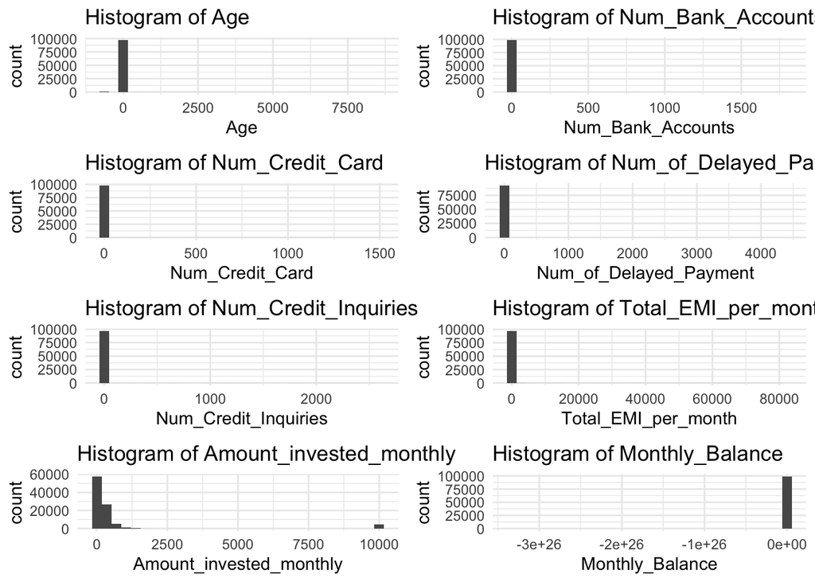

```r
hist_num_cols <- c("Age", "Num_Bank_Accounts", "Num_Credit_Card", "Num_of_Delayed_Payment", "Num_Credit_Inquiries", "Total_EMI_per_month", "Amount_invested_monthly", "Monthly_Balance")
par(mfrow = c(4,2))
suppressWarnings(suppressMessages(hist_num_plots <- lapply(hist_num_cols, function(column_name) {
  ggplot(data, aes(x = !!sym(column_name))) +
    geom_histogram() +
    theme_minimal() +
    labs(title = paste("Histogram of", column_name), x = column_name)
})))

suppressWarnings(suppressMessages(grid.arrange(grobs = hist_num_plots, ncol = 2))) ## display plot
```

**Interpretation:**  
We can see that because of outliers, the distribution of these columns become very skewed, which is not normal.

**3.3. Check unique values by each customer**

```r
checking_col <- c("Age", "Annual_Income", "Num_Bank_Accounts", "Num_Credit_Card", "Interest_Rate", "Num_of_Loan", "Num_of_Delayed_Payment", "Num_Credit_Inquiries", "Outstanding_Debt", "Total_EMI_per_month")
check_results <- sapply(checking_col, function(x) {
  result <- analyze_unique_values(x)
  return (result)
})

unique_check_df <- data.frame(Columns = checking_col, HasUniqueValuePerCustomer = check_results, row.names = NULL)
unique_check_df
```

```
##                   Columns HasUniqueValuePerCustomer
## 1                     Age                     FALSE
## 2           Annual_Income                      TRUE
## 3       Num_Bank_Accounts                     FALSE
## 4         Num_Credit_Card                     FALSE
## 5           Interest_Rate                      TRUE
## 6             Num_of_Loan                      TRUE
## 7  Num_of_Delayed_Payment                     FALSE
## 8    Num_Credit_Inquiries                     FALSE
## 9        Outstanding_Debt                      TRUE
## 10    Total_EMI_per_month                     FALSE
```

**Interpretation:**  
Excluding the outliers (very large abnormal number), there are some columns only have 1 value per customer. Therefore, it’s likely that these are the outliers appearing because of some mistakes in data collecting process. For those columns with FALSE result, after having further inspection, we could see that although these columns have more than 1 value per customer, these values are also duplicated within 1 customer group, except the outliers. Also, these duplicated values are in ordered from top to bottom within that group. Conclusively, we plan to replace the outliers in “TRUE” columns with mode value of each customer and replace the outliers in “FALSE” columns with nearest neighbor value.

**3.4. Check value for Credit_Utilization_Ratio column**

```r
out_of_range <- data %>%
  filter(Credit_Utilization_Ratio < 0 | Credit_Utilization_Ratio > 100)
if(nrow(out_of_range) > 0) {
  print("There are values outside the 0 to 100 range")
} else {
  print("All values are in 0 to 100 range")
}
```

```
## [1] "All values are in 0 to 100 range"
```

**4. Modify data values**

**4.1. Unique value columns**  
For these columns, we clean the outliers with the mode from each group

```r
data <- clean_data_with_mode("Annual_Income")
data <- clean_data_with_mode("Interest_Rate")
data <- clean_data_with_mode("Num_of_Loan")
data <- clean_data_with_mode("Outstanding_Debt")
```

**4.2. Non-unique value columns**  
For these columns, we clean the outliers with the data from nearest neighbor

```r
upper_bound_age <- calculate_bounds("Age")[2]
data <- clean_data_with_neighbor("Age", 0, upper_bound_age)

upper_bound_num_bank_acc <- calculate_bounds("Num_Bank_Accounts")[2]
data <- clean_data_with_neighbor("Num_Bank_Accounts", 0, upper_bound_num_bank_acc)

upper_bound_num_credit_card <- calculate_bounds("Num_Credit_Card")[2]
data <- clean_data_with_neighbor("Num_Credit_Card", 0, upper_bound_num_credit_card)

data <- fill_NA_with_neighbour("Num_of_Delayed_Payment")
upper_bound_num_delay_payment <- calculate_bounds("Num_of_Delayed_Payment")[2]
data <- clean_data_with_neighbor("Num_of_Delayed_Payment", 0, upper_bound_num_delay_payment)

data <- fill_NA_with_neighbour("Num_Credit_Inquiries")
upper_bound_num_credit_inquires <- calculate_bounds("Num_Credit_Inquiries")[2]
data <- clean_data_with_neighbor("Num_Credit_Inquiries", 0, upper_bound_num_credit_inquires)

lower_bound <- calculate_bounds("Total_EMI_per_month")[1]
upper_bound_total_emi <- calculate_bounds("Total_EMI_per_month")[2]
data <- clean_data_with_neighbor("Total_EMI_per_month", 0, 1800) # this column has upper_bound to low, which makes value of some group becomes outlier; therefore, we decide to choose the value of 1800; which is the maximum of valid values among every customer.
```

**4.3. Other columns**

```r
data <- fill_NA_with_neighbour("Monthly_Inhand_Salary")
data <- replace_negative_with_0("Delay_from_due_date")
data <- fill_NA_with_mean("Changed_Credit_Limit")
data <- data %>%
  group_by(Customer_ID) %>%
  mutate(Index = row_number()) %>%
  arrange(Customer_ID, Index) %>%
  mutate(First_Valid = min(Index[!is.na(Credit_History_Age)])) %>%
  mutate(Base = Credit_History_Age[First_Valid] - First_Valid) %>%
  mutate(Credit_History_Age = if_else(is.na(Credit_History_Age), Index + Base, Credit_History_Age)) %>%
  select(-Index, -First_Valid, -Base) %>%
  ungroup()
data <- replace_with_group_mean("Amount_invested_monthly", 10000)
data <- data %>%
  mutate(Monthly_Balance = ifelse(Monthly_Balance == -333333333333333333333333333, 333333333333333333333333333, Monthly_Balance))
data <- replace_with_group_mean("Monthly_Balance", 333333333333333333333333333)
```

## 3.3 Categorical variables

**1. Change data type to Factor**

```r
categorical_var <- c("Month","Occupation", "Credit_Mix", "Payment_of_Min_Amount", "Payment_Behaviour", "Credit_Score")
data[categorical_var] <- lapply(data[categorical_var], as.factor)
```

**2. Check distribution**

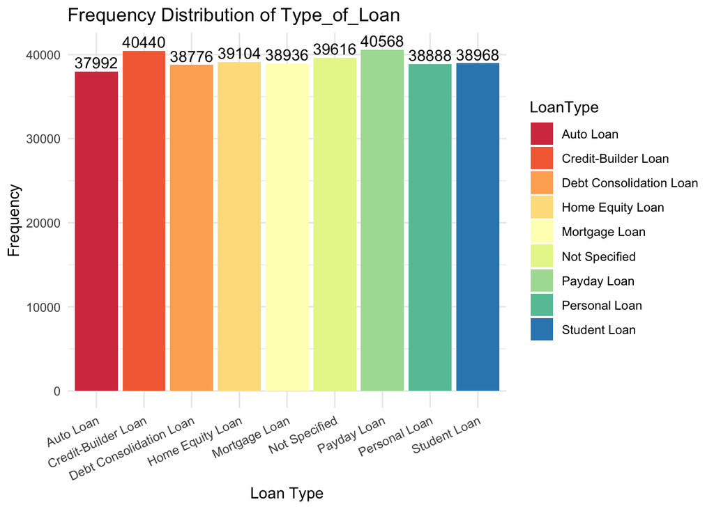

```r
# Remove all "and "
data$Type_of_Loan <- gsub("and ", "", data$Type_of_Loan)
# Split by ", "
splitLoans <- strsplit(data$Type_of_Loan, ", ", fixed = TRUE)
# Flatten the list to a vector
loanTypes <- unlist(splitLoans)
# Count the frequency of each text
loanTypeFrequency <- table(loanTypes)
loanTypeFrequencyDF <- as.data.frame(loanTypeFrequency)
colnames(loanTypeFrequencyDF) <- c("LoanType", "Frequency")

type_of_loan_plot <- ggplot(loanTypeFrequencyDF, aes(x = LoanType, y = Frequency, fill = LoanType)) +
  geom_bar(stat = "identity") +
  geom_text(aes(label = Frequency), vjust = -0.3, color = "black") +
  theme_minimal() +
  labs(title = "Frequency Distribution of Type_of_Loan", x = "Loan Type", y = "Frequency") +
  theme(axis.text.x = element_text(angle = 25, hjust = 1)) +
  scale_fill_brewer(palette = "Spectral")
type_of_loan_plot
```

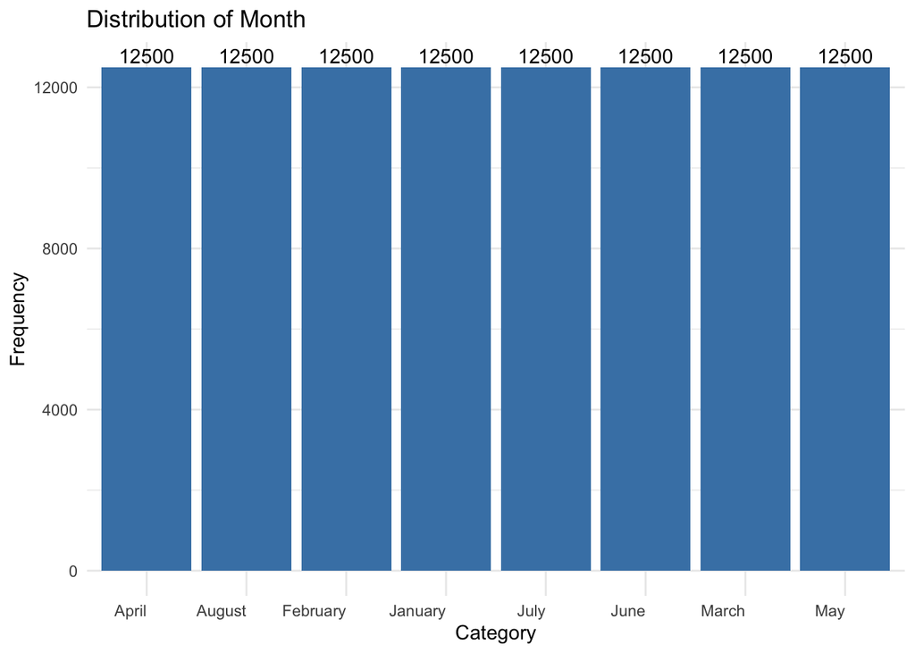

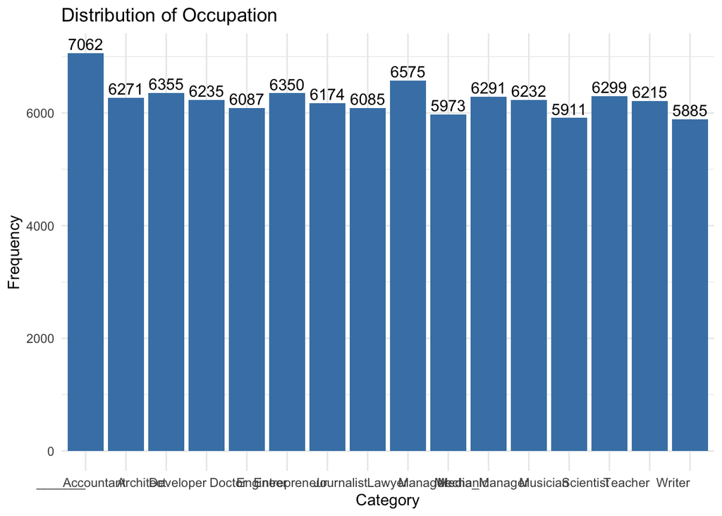

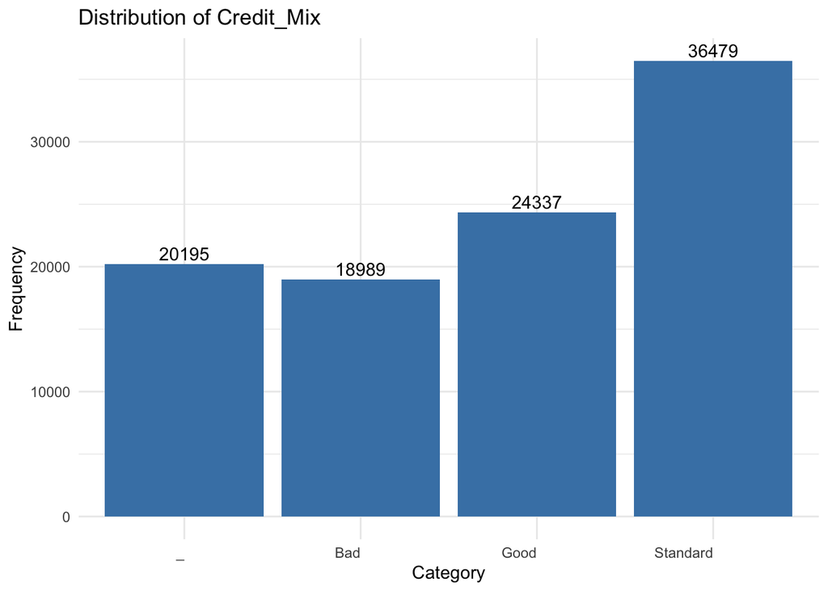

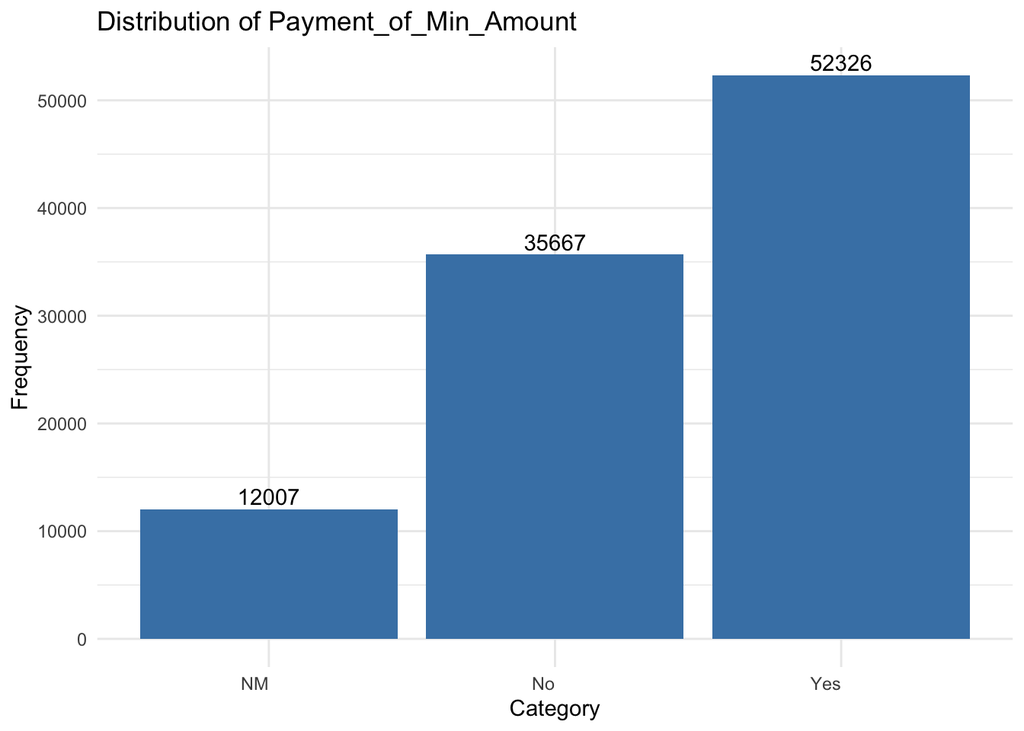

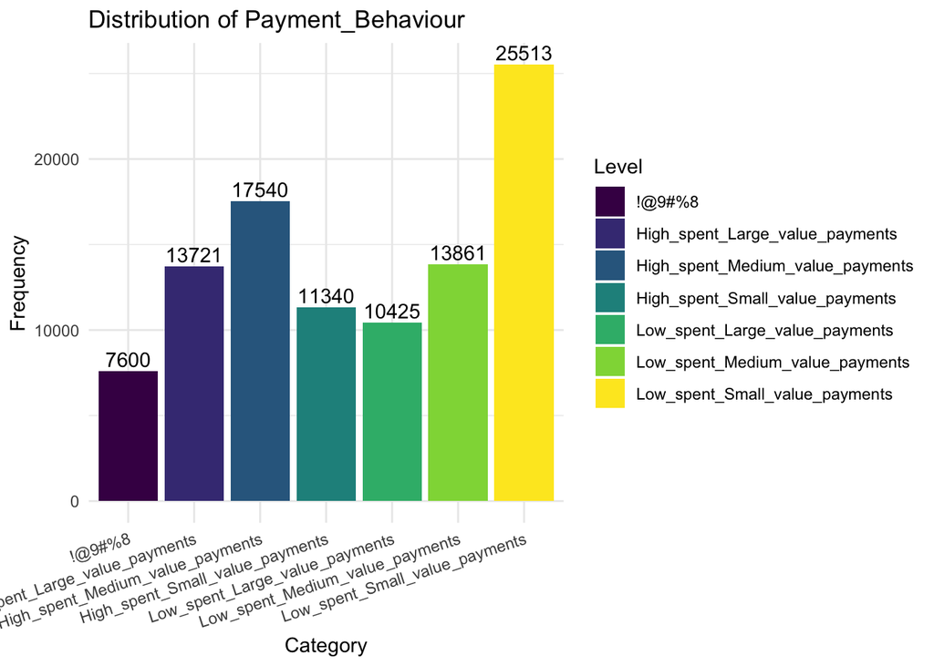

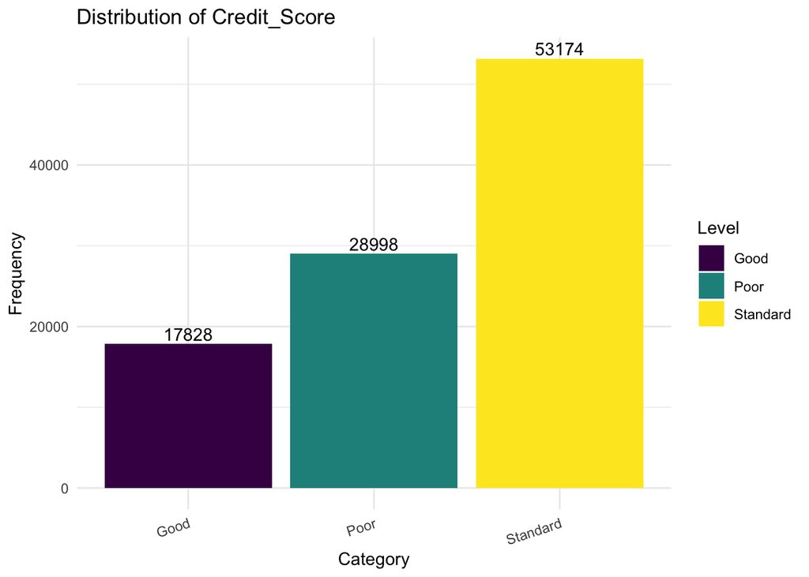

```r
plot_list_1 <- lapply(c("Month", "Occupation", "Credit_Mix", "Payment_of_Min_Amount"), function(col) {
    frequency <- table(data[col])
    frequencyDF <- as.data.frame(frequency)
    names(frequencyDF) <- c("Level", "Frequency")
    return (ggplot(frequencyDF, aes(x = Level, y = Frequency)) +
      geom_bar(stat = "identity", fill = "steelblue") +
      geom_text(aes(label = Frequency), vjust = -0.3, color = "black") +
      theme_minimal() +
      labs(title = paste("Distribution of", col), x = "Category", y = "Frequency") +
      theme(axis.text.x = element_text(angle = 0, hjust = 1)))
})

plot_list_2 <- lapply(c("Payment_Behaviour", "Credit_Score"), function(col) {
    frequency <- table(data[col])
    frequencyDF <- as.data.frame(frequency)
    names(frequencyDF) <- c("Level", "Frequency")

    return(ggplot(frequencyDF, aes(x = Level, y = Frequency, fill = Level)) +
      geom_bar(stat = "identity") +
      geom_text(aes(label = Frequency), vjust = -0.3, color = "black") +
      theme_minimal() +
      labs(title = paste("Distribution of", col), x = "Category", y = "Frequency") +
      theme(axis.text.x = element_text(angle = 18, hjust = 1)) +
      scale_fill_viridis_d())
})
plot_list <- c(plot_list_1, plot_list_2)
plot_list
```

**Interpretation:**  
We could see that there are 4 variables have invalid values, which are Occupation, Payment_Behaviour, Credit_Mix, and Payment_of_Min_Amount

**3. Check % of missing/invalid values**

```r
missing_val_check_col <- c("Month", "Type_of_Loan", "Occupation", "Credit_Mix" , "Payment_of_Min_Amount", "Payment_Behaviour" , "Credit_Score")
invalid_val <- c("", "", "_______", "_", "NM", "!@9#%8", "")
invalid_val_col <- setNames(as.list(invalid_val), missing_val_check_col)
num_na_list <- sapply(missing_val_check_col, function(x) {
  return (sum(is.na(data[x])))
})
num_invalid_list <- sapply(missing_val_check_col, function(x) {
  return (sum(data[x] == invalid_val_col[x]))
})
percentage_invalid_val_list <- sapply(num_invalid_list, function(x) {
  return((x / nrow(data)) * 100)
})

missing_val_percentage_df <- data.frame(Columns = missing_val_check_col, NumberOfNA = num_na_list, NumberOfInvalidValue = num_invalid_list, PercentageOfInvalidVal = percentage_invalid_val_list, row.names = NULL)
missing_val_percentage_df
```

```
##                 Columns NumberOfNA NumberOfInvalidValue PercentageOfInvalidVal
## 1                 Month          0                    0                  0.000
## 2          Type_of_Loan          0                11408                 11.408
## 3            Occupation          0                 7062                  7.062
## 4            Credit_Mix          0                20195                 20.195
## 5 Payment_of_Min_Amount          0                12007                 12.007
## 6     Payment_Behaviour          0                 7600                  7.600
## 7          Credit_Score          0                    0                  0.000
```

**Interpretation:**  
We can see that for Month and Credit_Score variable, there is no missing/invalid value. However for the other variables, there are many missing/invalid values, which have a relatively high percentage. Therefore, we decided to replace these values rather than deleting them.

**4. Check if excluding invalid value, the values are unique by each customer group**

```r
inv_col_check <- c("Occupation", "Credit_Mix" , "Payment_of_Min_Amount", "Payment_Behaviour")
invalid_val_1 <- c("_______", "_", "NM", "!@9#%8")
invalid_val_1_col <- setNames(as.list(invalid_val_1), inv_col_check)

count_unique_value <- function(column_name, bad_value) {
  col_sym <- rlang::sym(column_name)
  df_without_invalid_val <- data[data[column_name] != bad_value,  c("Customer_ID", column_name)]
  count_val <- unique(df_without_invalid_val %>% group_by(Customer_ID, !!(col_sym)))
  return(sum(duplicated(count_val$Customer_ID)))
}

check_inv_result <- sapply(inv_col_check, function(x) {
  result <- count_unique_value(x, invalid_val_1_col[x])
  return (result == 0)
})

unique_val_cat_df <- data.frame(Column = inv_col_check, HasUniqueValuePerCustomer = check_inv_result, row.names = NULL)
unique_val_cat_df
```

```
##                  Column HasUniqueValuePerCustomer
## 1            Occupation                      TRUE
## 2            Credit_Mix                      TRUE
## 3 Payment_of_Min_Amount                      TRUE
## 4     Payment_Behaviour                     FALSE
```

**Interpretation:**  
We can see that except Payment_Behavior, the other variables have only 1 value per customer (exclude the invalid value). Also, after further inspecting Payment_Behavior, except the invalid values, the other values are comprehendable. Therefore, we decided to replace these invalid values for these 4 columns with the mode of each customer. For the columns has unique value per customer, the mode of 1 customer is also that unique value.

**5. Handle missing/invalid values**

**5.1. Handle Type_of_Loan column**

It has been observed that when the values in the Num_of_Loan column are 0 or negative, there still exists some content in the Type_of_Loan column(e.g “Not Specified”). It is considered that a loan count of 0 or negative effectively means there is no loan type. Therefore, the values in the Type_of_Loan column corresponding to 0 or negative values in the Num_of_Loan column should be set to “No_Loan”.

```r
# Set Type_of_Loan to "No Loan" where Num_of_Loan is 0 or negative
data$Type_of_Loan <- ifelse(data$Num_of_Loan <= 0, "No Loan", data$Type_of_Loan)
```

**5.2. Handle the other columns**  
For these columns, we replace the invalid values with mode of each group

```r
find_mode_except_bad_value <- function(x, bad_value) {
  ux <- unique(na.omit(x[x != bad_value]))
  ux[which.max(tabulate(match(x, ux)))]
}

data <- data %>%
  group_by(Customer_ID) %>%
  mutate(Mode_Occupation = find_mode_except_bad_value(Occupation, '_______'),
         Occupation = if_else(Occupation == '_______', Mode_Occupation, Occupation),
         Mode_Credit_Mix = find_mode_except_bad_value(Credit_Mix, '_'),
         Credit_Mix = if_else(Credit_Mix == '_', Mode_Credit_Mix, Credit_Mix),
         Mode_Payment_of_Min_Amount = find_mode_except_bad_value(Payment_of_Min_Amount, 'NM'),
         Payment_of_Min_Amount = if_else(Payment_of_Min_Amount == 'NM', Mode_Payment_of_Min_Amount, Payment_of_Min_Amount),
          Mode_Payment_Behaviour = find_mode_except_bad_value(Payment_Behaviour, '!@9#%8'),
         Payment_Behaviour = if_else(Payment_Behaviour == '!@9#%8', Mode_Payment_Behaviour, Payment_Behaviour)) %>%
  select(-c(Mode_Occupation, Mode_Credit_Mix, Mode_Payment_of_Min_Amount, Mode_Payment_Behaviour)) %>%
  ungroup()
```

**6. Assign dummy values to categorical variables**

```r
data <- data %>%
  mutate(
    Month_numeric = case_when(
      Month == "January" ~ 1,
      Month == "February" ~ 2,
      Month == "March" ~ 3,
      Month == "April" ~ 4,
      Month == "May" ~ 5,
      Month == "June" ~ 6,
      Month == "July" ~ 7,
      Month == "August" ~ 8,
      TRUE ~ NA_real_
    ),
    Occupation_numeric = case_when(
      Occupation == "Scientist" ~ 1,
      Occupation == "Teacher" ~ 2,
      Occupation == "Engineer" ~ 3,
      Occupation == "Entrepreneur" ~ 4,
      Occupation == "Developer" ~ 5,
      Occupation == "Lawyer" ~ 6,
      Occupation == "Media_Manager" ~ 7,
      Occupation == "Doctor" ~ 8,
      Occupation == "Journalist" ~ 9,
      Occupation == "Manager" ~ 10,
      Occupation == "Accountant" ~ 11,
      Occupation == "Musician" ~ 12,
      Occupation == "Mechanic" ~ 13,
      Occupation == "Writer" ~ 14,
      Occupation == "Architect" ~ 15,
      TRUE ~ NA_real_
    ),
    Credit_Mix_numeric = case_when(
      Credit_Mix == "Bad" ~ 1,
      Credit_Mix == "Standard" ~ 2,
      Credit_Mix == "Good" ~ 3,
      TRUE ~ NA_real_
    ),
    Payment_of_Min_Amount_numeric = case_when(
      Payment_of_Min_Amount == "No" ~ 0,
      Payment_of_Min_Amount == "Yes" ~ 1,
      TRUE ~ NA_real_
    ),
    Payment_Behaviour_numeric = case_when(
      Payment_Behaviour == "High_spent_Large_value_payments" ~ 6,
      Payment_Behaviour == "High_spent_Medium_value_payments" ~ 5,
      Payment_Behaviour == "High_spent_Small_value_payments" ~ 4,
      Payment_Behaviour == "Low_spent_Large_value_payments" ~ 3,
      Payment_Behaviour == "Low_spent_Medium_value_payments" ~ 2,
      Payment_Behaviour == "Low_spent_Small_value_payments" ~ 1,
      TRUE ~ NA_real_
    ),
    Credit_Score_numeric = case_when(
      Credit_Score == "Poor" ~ 1,
      Credit_Score == "Standard" ~ 2,
      Credit_Score == "Good" ~ 3,
      TRUE ~ NA_real_
    )
  )
```

## 3.4 Check cleaned dataset

**1. Numerical variables**

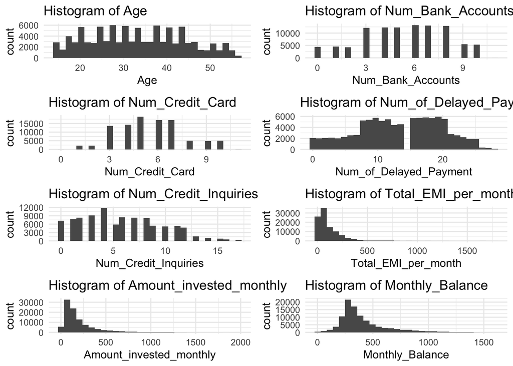

```r
hist_num_cols <- c("Age", "Num_Bank_Accounts", "Num_Credit_Card", "Num_of_Delayed_Payment", "Num_Credit_Inquiries", "Total_EMI_per_month", "Amount_invested_monthly", "Monthly_Balance")
par(mfrow = c(4,2))
suppressMessages(hist_num_plots <- lapply(hist_num_cols, function(column_name) {
  ggplot(data, aes(x = !!sym(column_name))) +
    geom_histogram() +
    theme_minimal() +
    labs(title = paste("Histogram of", column_name), x = column_name)
}))
suppressMessages(grid.arrange(grobs = hist_num_plots, ncol = 2)) ## display plot
```

**Conclusion:**  
We could see that the distribution of numerical variables are improved  
**2. Categorical variables**

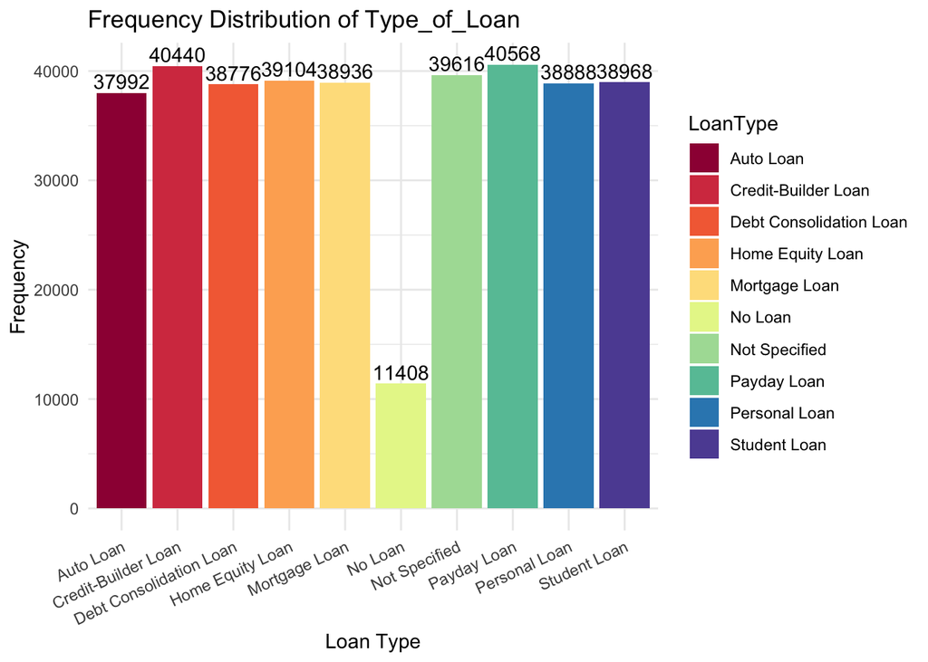

```r
# Remove all "and "
data$Type_of_Loan <- gsub("and ", "", data$Type_of_Loan)
# Split by ", "
splitLoans <- strsplit(data$Type_of_Loan, ", ", fixed = TRUE)
# Flatten the list to a vector
loanTypes <- unlist(splitLoans)
# Count the frequency of each text
loanTypeFrequency <- table(loanTypes)
loanTypeFrequencyDF <- as.data.frame(loanTypeFrequency)
colnames(loanTypeFrequencyDF) <- c("LoanType", "Frequency")

type_of_loan_plot <- ggplot(loanTypeFrequencyDF, aes(x = LoanType, y = Frequency, fill = LoanType)) +
  geom_bar(stat = "identity") +
  geom_text(aes(label = Frequency), vjust = -0.3, color = "black") +
  theme_minimal() +
  labs(title = "Frequency Distribution of Type_of_Loan", x = "Loan Type", y = "Frequency") +
  theme(axis.text.x = element_text(angle = 25, hjust = 1)) +
  scale_fill_brewer(palette = "Spectral")
type_of_loan_plot
```

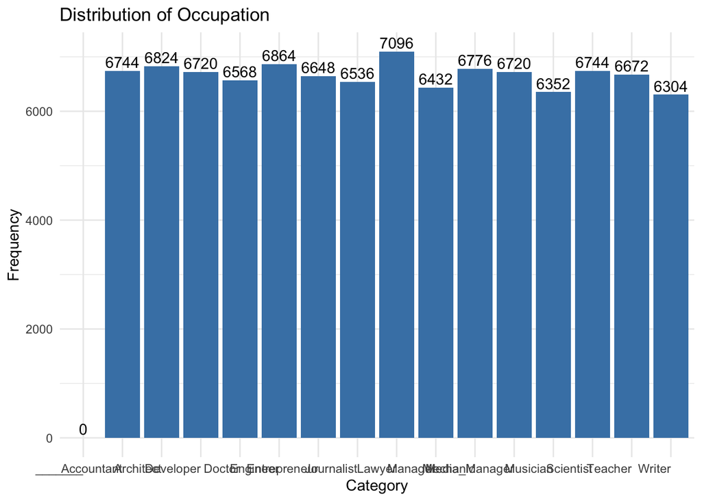

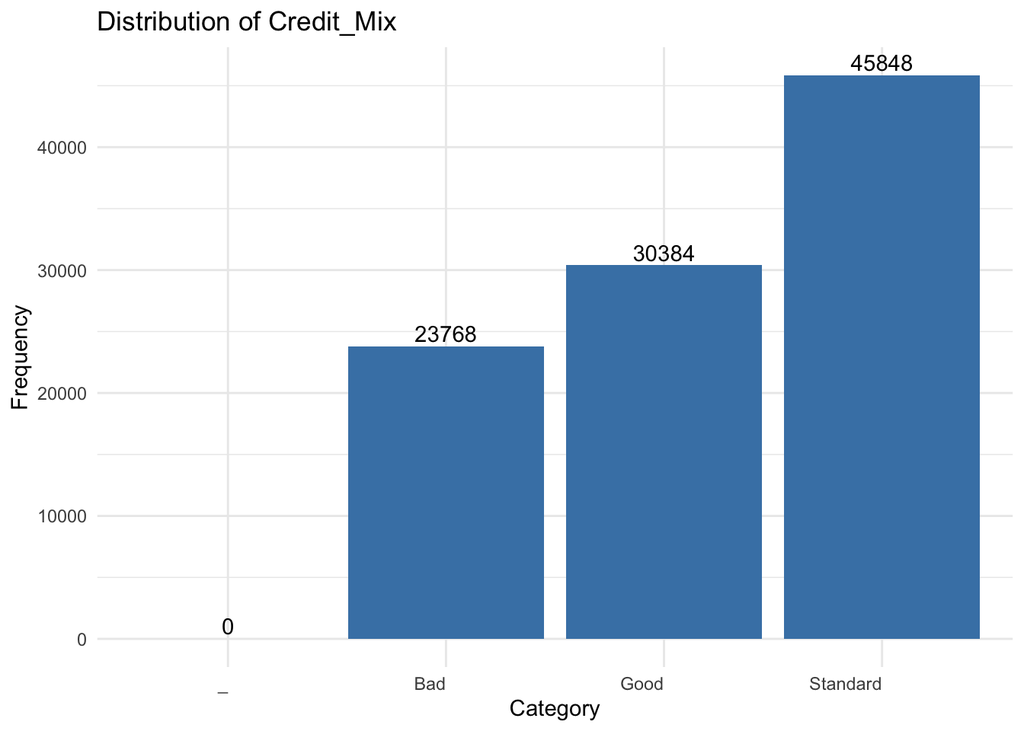

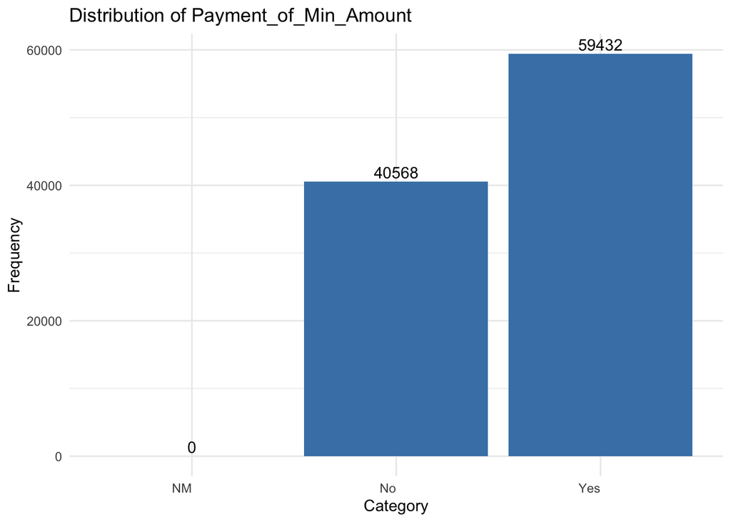

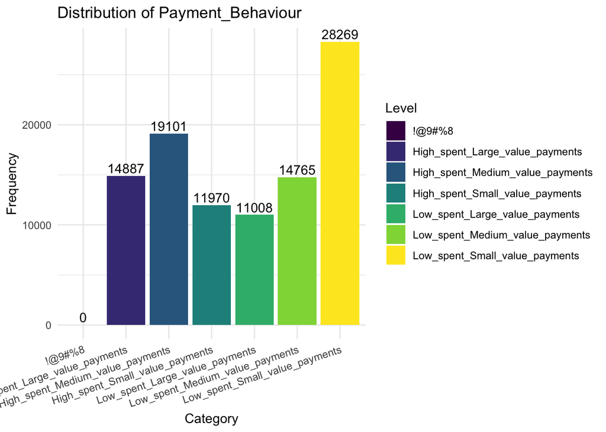

```r
plot_list_1 <- lapply(c("Occupation", "Credit_Mix", "Payment_of_Min_Amount"), function(col) {
    frequency <- table(data[col])
    frequencyDF <- as.data.frame(frequency)
    names(frequencyDF) <- c("Level", "Frequency")
    return (ggplot(frequencyDF, aes(x = Level, y = Frequency)) +
      geom_bar(stat = "identity", fill = "steelblue") +
      geom_text(aes(label = Frequency), vjust = -0.3, color = "black") +
      theme_minimal() +
      labs(title = paste("Distribution of", col), x = "Category", y = "Frequency") +
      theme(axis.text.x = element_text(angle = 0, hjust = 1)))
})

plot_list_2 <- lapply(c("Payment_Behaviour"), function(col) {
    frequency <- table(data[col])
    frequencyDF <- as.data.frame(frequency)
    names(frequencyDF) <- c("Level", "Frequency")

    return(ggplot(frequencyDF, aes(x = Level, y = Frequency, fill = Level)) +
      geom_bar(stat = "identity") +
      geom_text(aes(label = Frequency), vjust = -0.3, color = "black") +
      theme_minimal() +
      labs(title = paste("Distribution of", col), x = "Category", y = "Frequency") +
      theme(axis.text.x = element_text(angle = 18, hjust = 1)) +
      scale_fill_viridis_d())
})
plot_list <- c(plot_list_1, plot_list_2)
plot_list
```

**Conclusion:**  
We could see that there are no more missing/invalid values

# 4 EDA

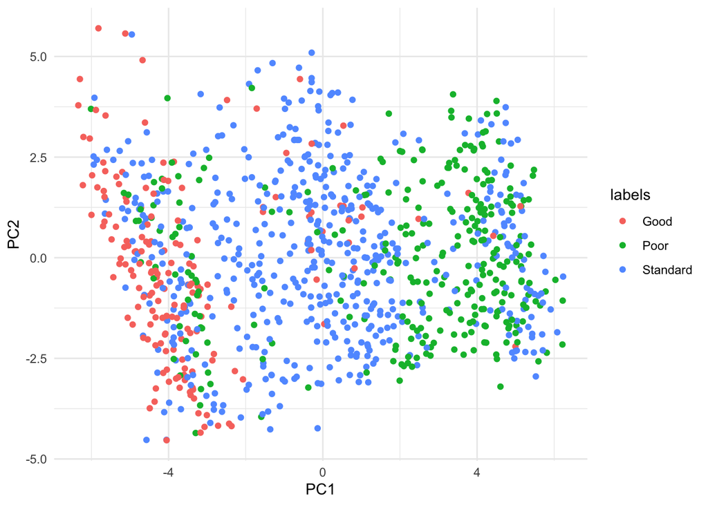

```r
pca.data <- data[, -which(names(data) %in% c("Customer_ID"))] %>% sample_n(1000)
data.att <- select(pca.data, -'Credit_Score')
data.att <- model.matrix(~ . - 1, data = data.att)
credit_score <- factor(pca.data[["Credit_Score"]])
pca.scaled <- prcomp(data.att, scale = TRUE)
credit_score.df <- data.frame(PC1 = pca.scaled$x[, 1], PC2 = pca.scaled$x[, 2], PC3 = pca.scaled$x[, 3], labels = credit_score)
pca.plot <- ggplot(credit_score.df, aes(PC1, PC2, col = labels)) + geom_point() + theme_minimal()
print(pca.plot)
```

# 5 Project Plan

[output not shown]